# Prosper Loan

## by AWOLAJU Saheed

## Investigation Overview

##### The aim of this presentation is to show the conclusions and insights that I have been able derive from the exploration of the dataset, which mainly is to explain the key variables out of the lots that determines whether a borrower will be able to pay back his/her loan in the nearest future.

## Dataset Overview

##### The dataset is data collected over the year about the borrowers of a loan provider. We have 113,937 observations and 81 collectable data per loan.

## Relationship between DebitToIncomeRatio,CreditGrade and LoanStatus

##### Those with a CreditGrades AA,A,B,C also have a higher number of completed loan and less defaulters compared to those with CreditGrades E,HR,NC that higher amount of defaulters and charge-offs

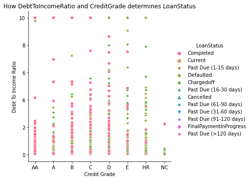

## The Effect of BorrowerRate and LoanOriginalAmount on LoanStatus

##### Borrowers with a relatively lower loan (less than $5000) are completing their payments compared to those a higher loan amount.

##### Also, the higher number of borrowers with BorrowerRate of less than 0.25 are completing their loan or are in the final payment.

##### Most of the defaulters and charge-off were borrowers who had a loan of over $5000 or borrowed at a rate higher than 0.25

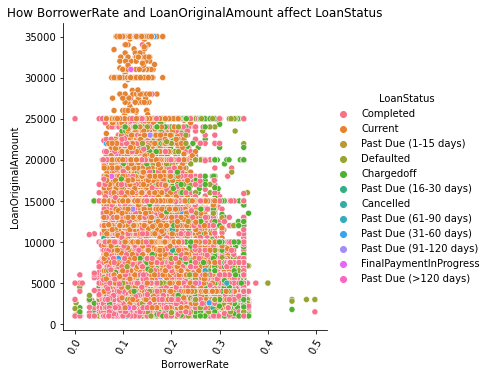

## Effect of Term and IncomeRange on LoanOriginalAmount

#### Earners of over 100,000 are the highest borrowers in terms of loan amount.

#### The LOANORIGINALAMOUNT does not affect the TERM( It is very likely to choosen by the borrower)

#### Borrowers earning less than 100,000 rarely borrow more than 25000

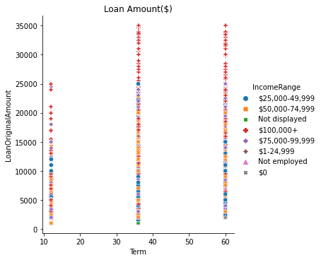